# CarPrice

Importing Libraries

```python
import pandas as pd
import numpy as np
import matplotlib.pyplot as plt
import seaborn as sns
```

Loading Dataset

```python
df=pd.read_csv("car_price_dataset.csv")
```

Data Overview

```python
df.head()
```

|  | Brand | Model | Year | Engine_Size | Fuel_Type | Transmission | Mileage | Doors | Owner_Count | Price |
| --- | --- | --- | --- | --- | --- | --- | --- | --- | --- | --- |
| 0 | Kia | Rio | 2020 | 4.2 | Diesel | Manual | 289944 | 3 | 5 | 8501 |
| 1 | Chevrolet | Malibu | 2012 | 2.0 | Hybrid | Automatic | 5356 | 2 | 3 | 12092 |
| 2 | Mercedes | GLA | 2020 | 4.2 | Diesel | Automatic | 231440 | 4 | 2 | 11171 |
| 3 | Audi | Q5 | 2023 | 2.0 | Electric | Manual | 160971 | 2 | 1 | 11780 |
| 4 | Volkswagen | Golf | 2003 | 2.6 | Hybrid | Semi-Automatic | 286618 | 3 | 3 | 2867 |

```python
df.info()
```

```
<class 'pandas.core.frame.DataFrame'>
RangeIndex: 10000 entries, 0 to 9999
Data columns (total 10 columns):
 #   Column        Non-Null Count  Dtype
---  ------        --------------  -----
 0   Brand         10000 non-null  object
 1   Model         10000 non-null  object
 2   Year          10000 non-null  int64
 3   Engine_Size   10000 non-null  float64
 4   Fuel_Type     10000 non-null  object
 5   Transmission  10000 non-null  object
 6   Mileage       10000 non-null  int64
 7   Doors         10000 non-null  int64
 8   Owner_Count   10000 non-null  int64
 9   Price         10000 non-null  int64
dtypes: float64(1), int64(5), object(4)
memory usage: 781.4+ KB
```

observations: .The dataset consists of 10000 examples and 9 features .The dataset contains 6 numerical columns(5 of int type,1 of float type) and 4 categorical columns-brand,model,fuel type etc .The target varibale is Price.

```python
df.describe()
```

|  | Year | Engine_Size | Mileage | Doors | Owner_Count | Price |
| --- | --- | --- | --- | --- | --- | --- |
| count | 10000.000000 | 10000.000000 | 10000.000000 | 10000.000000 | 10000.000000 | 10000.00000 |
| mean | 2011.543700 | 3.000560 | 149239.111800 | 3.497100 | 2.991100 | 8852.96440 |
| std | 6.897699 | 1.149324 | 86322.348957 | 1.110097 | 1.422682 | 3112.59681 |
| min | 2000.000000 | 1.000000 | 25.000000 | 2.000000 | 1.000000 | 2000.00000 |
| 25% | 2006.000000 | 2.000000 | 74649.250000 | 3.000000 | 2.000000 | 6646.00000 |
| 50% | 2012.000000 | 3.000000 | 149587.000000 | 3.000000 | 3.000000 | 8858.50000 |
| 75% | 2017.000000 | 4.000000 | 223577.500000 | 4.000000 | 4.000000 | 11086.50000 |
| max | 2023.000000 | 5.000000 | 299947.000000 | 5.000000 | 5.000000 | 18301.00000 |

observations: .The average Engine size is 3 litres.The std of 1.15 shows there is significant variation in the engine size, which could affect car prices. .The cars in the dataset range from the year 2000 to 2023, which gives a sense of how new and old the cars are. .The average number of owners per car is about 2.99, meaning that on average, a car in this dataset has had nearly 3 previous owners.The minimum number of owners is 1 (indicating a first-hand owner), and the maximum is 5.

```python
df.describe(include='object').T
```

|  | count | unique | top | freq |
| --- | --- | --- | --- | --- |
| Brand | 10000 | 10 | Ford | 1048 |
| Model | 10000 | 30 | Accord | 365 |
| Fuel_Type | 10000 | 4 | Electric | 2625 |
| Transmission | 10000 | 3 | Manual | 3372 |

observations: .The top brand is Ford,which counts about 1048. .The customers prefer Electric model and manual transmission. .Model Accord is top Model.

Exploratory Data Analysis

```python
df.head()
```

|  | Brand | Model | Year | Engine_Size | Fuel_Type | Transmission | Mileage | Doors | Owner_Count | Price |
| --- | --- | --- | --- | --- | --- | --- | --- | --- | --- | --- |
| 0 | Kia | Rio | 2020 | 4.2 | Diesel | Manual | 289944 | 3 | 5 | 8501 |
| 1 | Chevrolet | Malibu | 2012 | 2.0 | Hybrid | Automatic | 5356 | 2 | 3 | 12092 |
| 2 | Mercedes | GLA | 2020 | 4.2 | Diesel | Automatic | 231440 | 4 | 2 | 11171 |
| 3 | Audi | Q5 | 2023 | 2.0 | Electric | Manual | 160971 | 2 | 1 | 11780 |
| 4 | Volkswagen | Golf | 2003 | 2.6 | Hybrid | Semi-Automatic | 286618 | 3 | 3 | 2867 |

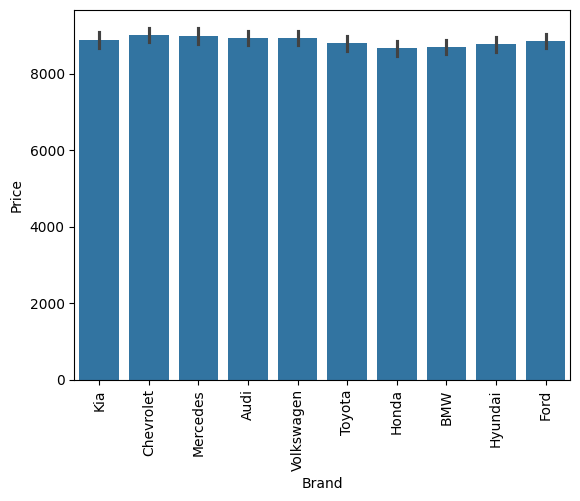

```
Brand
Chevrolet     9015.683948
Mercedes      8980.087049
Audi          8929.373796
Volkswagen    8928.377451
Kia           8880.086066
Ford          8852.570611
Toyota        8798.184536
Hyundai       8778.279397
BMW           8704.068068
Honda         8665.596630
Name: Price, dtype: float64
```

```python
sns.barplot(x='Brand',y='Price',data=df)
plt.xticks(rotation=90)
plt.show()
df.groupby('Brand')['Price'].mean().sort_values(ascending=False)
```

observations: .From above plot it is observed that the price ranges among brands are almost similar,Chevrolet being the highest followed by Mercedes.

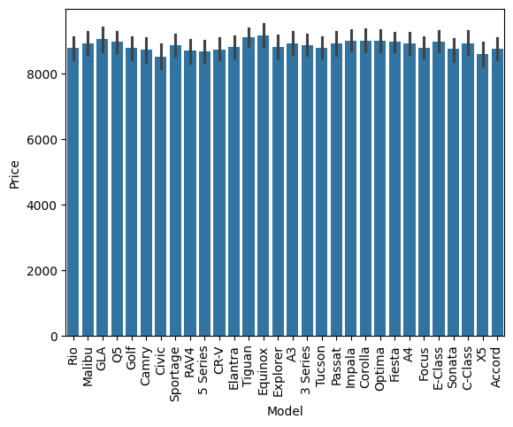

```
Model
Equinox     9156.320635
Tiguan      9098.863636
GLA         9049.844444
Impala      9001.115493
Corolla     8996.618462
Optima      8996.318452
Fiesta      8971.077135
E-Class     8967.330218
Q5          8955.257143
C-Class     8921.660131
A4          8919.962857
Passat      8914.072948
A3          8912.316568
Malibu      8898.180180
Sportage    8867.635783
3 Series    8854.752239
Explorer    8804.895210
Elantra     8802.475504
Tucson      8789.069909
Focus       8775.378917
Rio         8772.571865
Golf        8765.235988
Accord      8743.761644
Sonata      8740.830721
CR-V        8734.714286
Camry       8712.420561
RAV4        8684.108025
5 Series    8669.218130
X5          8581.311897
Civic       8517.327381
Name: Price, dtype: float64
```

```python
sns.barplot(x='Model',y='Price',data=df)
plt.xticks(rotation=90)
plt.show()
df.groupby('Model')['Price'].mean().sort_values(ascending=False)
```

observations: The Models prices also range almost same,the highest is Equinox,followed by Tiguan

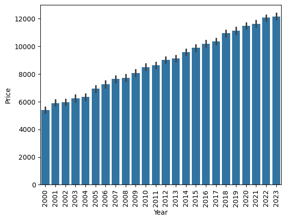

```
Year
2023    12169.470982
2022    12067.690176
2021    11637.813299
2020    11495.284337
2019    11132.722090
2018    10939.192941
2017    10343.757506
2016    10177.600000
2015     9896.774648
2014     9587.455635
2013     9114.208531
2012     9011.446224
2011     8622.855234
2010     8503.419954
2009     8083.917293
2008     7728.418848
2007     7632.513953
2006     7249.961446
2005     6943.037123
2004     6330.725888
2003     6225.834646
2002     5956.751082
2001     5904.064039
2000     5393.735369
Name: Price, dtype: float64
```

```python
sns.barplot(x='Year',y='Price',data=df)
plt.xticks(rotation=90)
plt.show()
df.groupby('Year')['Price'].mean().sort_values(ascending=False)
```

observations: .A clear pattern is observed,as new models (latest year models) have greater price than old models

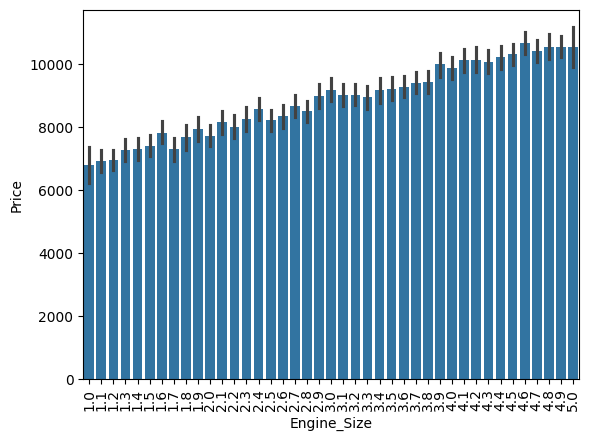

```
Engine_Size
4.6    10677.717557
4.9    10542.943320
4.8    10541.562771
5.0    10533.339806
4.7    10395.193676
4.5    10313.588000
4.4    10221.025830
4.2    10128.715517
4.1    10116.334630
4.3    10067.570248
3.9     9989.728814
4.0     9857.304183
3.8     9423.584980
3.7     9400.703297
3.6     9267.314607
3.5     9218.175781
3.0     9180.576271
3.4     9169.925926
3.2     9026.690763
3.1     9020.625984
2.9     8990.553360
3.3     8942.791339
2.7     8668.676000
2.4     8584.875000
2.8     8494.202290
2.6     8334.555985
2.3     8258.372197
2.5     8216.834586
2.1     8146.692308
2.2     7996.239382
1.9     7924.974138
1.6     7823.476744
2.0     7727.744186
1.8     7671.152610
1.5     7411.479245
1.4     7313.305019
1.7     7303.821138
1.3     7265.593870
1.2     6939.916335
1.1     6920.195652
1.0     6785.752212
Name: Price, dtype: float64
```

```python
sns.barplot(x='Engine_Size',y='Price',data=df)
plt.xticks(rotation=90)
plt.show()
df.groupby('Engine_Size')['Price'].mean().sort_values(ascending=False)
```

observations: .The prices of cars increased as the Enginee capacity increased.

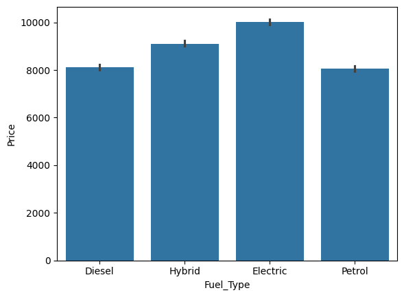

```
Fuel_Type
Electric    10032.220190
Hybrid       9113.030167
Diesel       8117.336385
Petrol       8070.561826
Name: Price, dtype: float64
```

```python
sns.barplot(x='Fuel_Type',y='Price',data=df)

plt.show()
df.groupby('Fuel_Type')['Price'].mean().sort_values(ascending=False)
```

observations: The prices of Electric cars is highest followed by Hybrid,diesel

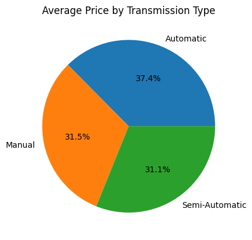

```python
avg_prices=df.groupby('Transmission')['Price'].mean().sort_values(ascending=False)
plt.pie(avg_prices,labels=avg_prices.index,autopct='%1.1f%%')
plt.title('Average Price by Transmission Type')
plt.show()
```

observations: The automatic cars have highest price followed by Manual and semi-automatic

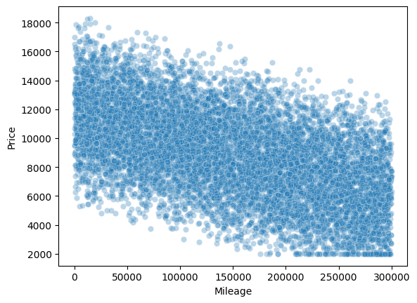

```
Mileage
14924     18301.0
12234     18255.0
19112     18017.0
14658     17906.0
10046     17899.0
           ...
296079     2000.0
278310     2000.0
298968     2000.0
297669     2000.0
297911     2000.0
Name: Price, Length: 9854, dtype: float64
```

```python
sns.scatterplot(x='Mileage',y='Price',data=df,alpha=0.3)

plt.show()
df.groupby('Mileage')['Price'].mean().sort_values(ascending=False)
```

observations: .From the above plot it is observed that,as the mileage increases(used vehicle) the prices drop

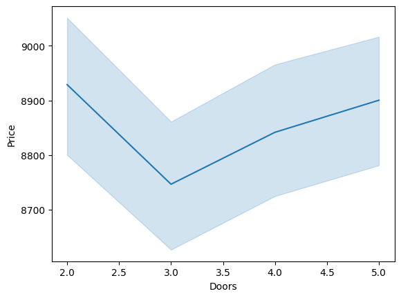

```python
sns.lineplot(x='Doors',y='Price',data=df)
plt.show()
```

observations: .The prices are low are cars with 3 doors,highest for cars with 2 doors

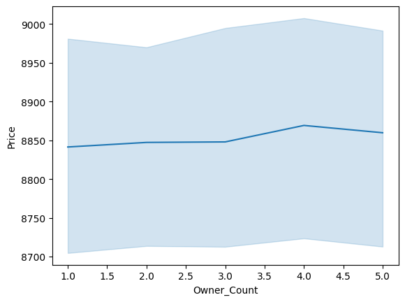

```
Owner_Count
4    8869.173485
5    8859.742141
3    8847.918563
2    8847.258416
1    8841.374263
Name: Price, dtype: float64
```

```python
sns.lineplot(x='Owner_Count',y='Price',data=df)
plt.show()
df.groupby('Owner_Count')['Price'].mean().sort_values(ascending=False)
```

observations:The owner_Count has less impact on prices,the price is highest for 4 owner counts.

Univariate Analysis

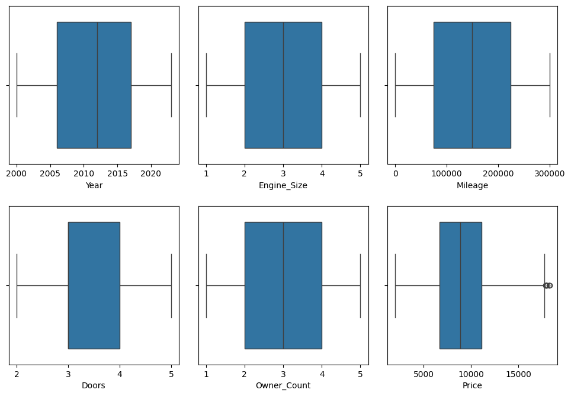

```python
num_cols=df.select_dtypes(include=np.number).columns.tolist()
plt.figure(figsize=(10,10))
for i,var in enumerate(num_cols):
    plt.subplot(3,3,i+1)
    sns.boxplot(x=var,data=df)
    plt.tight_layout(pad=2)
plt.show()
```

observations: There are no outliers present in dataset except for price. But,Prices can be exceptionally high in some cases,so we are not traeting outliers

Bivariate Analysis:

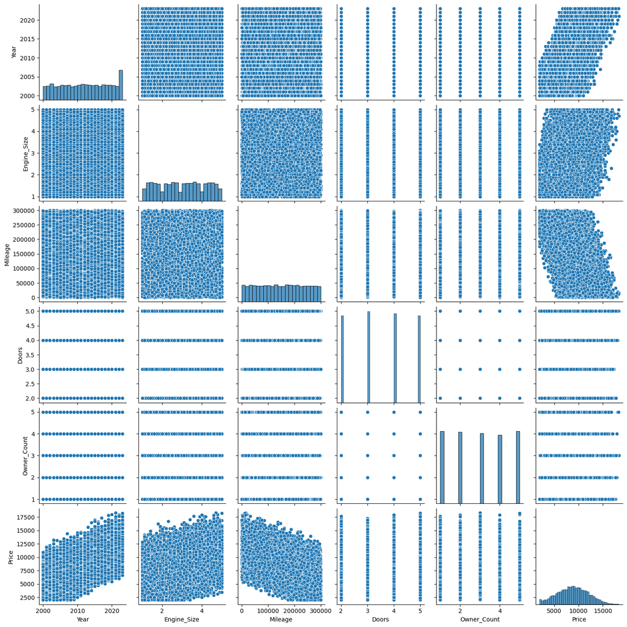

```python
sns.pairplot(data=df,kind='scatter')
```

observations: .There is a linear relationship between target and year,target and enginee size,target and mileage

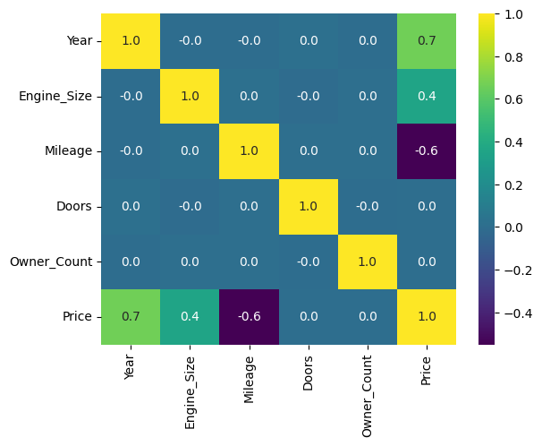

```python
num_cols=df.select_dtypes(include=np.number).columns.tolist()
df1=df[num_cols]
sns.heatmap(df1.corr(),annot=True,fmt=".1f",cmap='viridis')
plt.show()
```

observations: Year,Enginee size and mileage could be significant features in predicting prices

Feature Engineering

```python
#checking for null data
df.isnull().sum()
```

[output not shown]

observations:No null data observed

```python
#checking for duplicates
df.duplicated().sum()
```

```
np.int64(0)
```

observations:No duplicate entries found

```python
df.head()
```

[output not shown]

```python
#converting categorical data to numerical
df=pd.get_dummies(df,columns=df.select_dtypes(include=['object','category']).columns.tolist(),drop_first=True)
df.head()
```

|  | Year | Engine_Size | Mileage | Doors | Owner_Count | Price | Brand_BMW | Brand_Chevrolet | Brand_Ford | Brand_Honda | ... | Model_Sonata | Model_Sportage | Model_Tiguan | Model_Tucson | Model_X5 | Fuel_Type_Electric | Fuel_Type_Hybrid | Fuel_Type_Petrol | Transmission_Manual | Transmission_Semi-Automatic |
| --- | --- | --- | --- | --- | --- | --- | --- | --- | --- | --- | --- | --- | --- | --- | --- | --- | --- | --- | --- | --- | --- |
| 0 | 2020 | 4.2 | 289944 | 3 | 5 | 8501 | False | False | False | False | ... | False | False | False | False | False | False | False | False | True | False |
| 1 | 2012 | 2.0 | 5356 | 2 | 3 | 12092 | False | True | False | False | ... | False | False | False | False | False | False | True | False | False | False |
| 2 | 2020 | 4.2 | 231440 | 4 | 2 | 11171 | False | False | False | False | ... | False | False | False | False | False | False | False | False | False | False |
| 3 | 2023 | 2.0 | 160971 | 2 | 1 | 11780 | False | False | False | False | ... | False | False | False | False | False | True | False | False | True | False |
| 4 | 2003 | 2.6 | 286618 | 3 | 3 | 2867 | False | False | False | False | ... | False | False | False | False | False | False | True | False | False | True |

5 rows × 49 columns

```python
#explicity mapping False to 0 and True to 1
bool_cols=df.select_dtypes(include='bool').columns.tolist()
for col in bool_cols:
    df[col]=df[col].map({False:0,True:1})
df.head()
```

|  | Year | Engine_Size | Mileage | Doors | Owner_Count | Price | Brand_BMW | Brand_Chevrolet | Brand_Ford | Brand_Honda | ... | Model_Sonata | Model_Sportage | Model_Tiguan | Model_Tucson | Model_X5 | Fuel_Type_Electric | Fuel_Type_Hybrid | Fuel_Type_Petrol | Transmission_Manual | Transmission_Semi-Automatic |
| --- | --- | --- | --- | --- | --- | --- | --- | --- | --- | --- | --- | --- | --- | --- | --- | --- | --- | --- | --- | --- | --- |
| 0 | 2020 | 4.2 | 289944 | 3 | 5 | 8501 | 0 | 0 | 0 | 0 | ... | 0 | 0 | 0 | 0 | 0 | 0 | 0 | 0 | 1 | 0 |
| 1 | 2012 | 2.0 | 5356 | 2 | 3 | 12092 | 0 | 1 | 0 | 0 | ... | 0 | 0 | 0 | 0 | 0 | 0 | 1 | 0 | 0 | 0 |
| 2 | 2020 | 4.2 | 231440 | 4 | 2 | 11171 | 0 | 0 | 0 | 0 | ... | 0 | 0 | 0 | 0 | 0 | 0 | 0 | 0 | 0 | 0 |
| 3 | 2023 | 2.0 | 160971 | 2 | 1 | 11780 | 0 | 0 | 0 | 0 | ... | 0 | 0 | 0 | 0 | 0 | 1 | 0 | 0 | 1 | 0 |
| 4 | 2003 | 2.6 | 286618 | 3 | 3 | 2867 | 0 | 0 | 0 | 0 | ... | 0 | 0 | 0 | 0 | 0 | 0 | 1 | 0 | 0 | 1 |

5 rows × 49 columns

```python
#defining the features and traget variable
X=df.drop('Price',axis=1)
y=df['Price']
y.shape
```

```
(10000,)
```

```python
#splitting the dataset to train and test data
from sklearn.model_selection import train_test_split
X_train,X_test,y_train,y_test=train_test_split(X,y,test_size=0.3,random_state=42)
```

```python
print("No of entries in test data",X_test.shape[0])
print("No of entries in train data",X_train.shape[0])
```

```
No of entries in test data 3000
No of entries in train data 7000
```

```python
df.head()
```

|  | Year | Engine_Size | Mileage | Doors | Owner_Count | Price | Brand_BMW | Brand_Chevrolet | Brand_Ford | Brand_Honda | ... | Model_Sonata | Model_Sportage | Model_Tiguan | Model_Tucson | Model_X5 | Fuel_Type_Electric | Fuel_Type_Hybrid | Fuel_Type_Petrol | Transmission_Manual | Transmission_Semi-Automatic |
| --- | --- | --- | --- | --- | --- | --- | --- | --- | --- | --- | --- | --- | --- | --- | --- | --- | --- | --- | --- | --- | --- |
| 0 | 2020 | 4.2 | 289944 | 3 | 5 | 8501 | 0 | 0 | 0 | 0 | ... | 0 | 0 | 0 | 0 | 0 | 0 | 0 | 0 | 1 | 0 |
| 1 | 2012 | 2.0 | 5356 | 2 | 3 | 12092 | 0 | 1 | 0 | 0 | ... | 0 | 0 | 0 | 0 | 0 | 0 | 1 | 0 | 0 | 0 |
| 2 | 2020 | 4.2 | 231440 | 4 | 2 | 11171 | 0 | 0 | 0 | 0 | ... | 0 | 0 | 0 | 0 | 0 | 0 | 0 | 0 | 0 | 0 |
| 3 | 2023 | 2.0 | 160971 | 2 | 1 | 11780 | 0 | 0 | 0 | 0 | ... | 0 | 0 | 0 | 0 | 0 | 1 | 0 | 0 | 1 | 0 |
| 4 | 2003 | 2.6 | 286618 | 3 | 3 | 2867 | 0 | 0 | 0 | 0 | ... | 0 | 0 | 0 | 0 | 0 | 0 | 1 | 0 | 0 | 1 |

5 rows × 49 columns

```python
#normalizing the data
from sklearn.preprocessing import StandardScaler
scaler=StandardScaler()
col=['Mileage']
X_train[col]=scaler.fit_transform(X_train[col])
X_test[col]=scaler.transform(X_test[col])
```

```python
X_train.head()
```

|  | Year | Engine_Size | Mileage | Doors | Owner_Count | Brand_BMW | Brand_Chevrolet | Brand_Ford | Brand_Honda | Brand_Hyundai | ... | Model_Sonata | Model_Sportage | Model_Tiguan | Model_Tucson | Model_X5 | Fuel_Type_Electric | Fuel_Type_Hybrid | Fuel_Type_Petrol | Transmission_Manual | Transmission_Semi-Automatic |
| --- | --- | --- | --- | --- | --- | --- | --- | --- | --- | --- | --- | --- | --- | --- | --- | --- | --- | --- | --- | --- | --- |
| 9069 | 2002 | 4.8 | -1.095530 | 2 | 2 | 0 | 0 | 0 | 0 | 0 | ... | 0 | 0 | 0 | 0 | 0 | 0 | 0 | 1 | 0 | 0 |
| 2603 | 2020 | 2.2 | -0.022843 | 5 | 2 | 0 | 0 | 0 | 0 | 0 | ... | 0 | 0 | 0 | 0 | 0 | 0 | 1 | 0 | 0 | 1 |
| 7738 | 2011 | 1.3 | 0.373644 | 2 | 3 | 1 | 0 | 0 | 0 | 0 | ... | 0 | 0 | 0 | 0 | 0 | 0 | 0 | 1 | 0 | 0 |
| 1579 | 2010 | 1.3 | 0.523096 | 3 | 1 | 0 | 0 | 0 | 0 | 0 | ... | 0 | 1 | 0 | 0 | 0 | 0 | 1 | 0 | 0 | 1 |
| 5058 | 2015 | 1.7 | -1.602806 | 4 | 2 | 0 | 0 | 0 | 0 | 0 | ... | 0 | 0 | 0 | 0 | 0 | 0 | 0 | 0 | 1 | 0 |

5 rows × 48 columns

LinearRegression using sklearn

```python
from sklearn.linear_model import LinearRegression
model=LinearRegression()
model.fit(X_train,y_train)
```

```
LinearRegression()
```

```python
#creating an function to evaluate metrics
from sklearn.metrics import mean_absolute_error,mean_squared_error,r2_score
def metrics_evaluation(model,predictors,target):
    #predicting values of  data
    y_pred=model.predict(predictors)
    #evaluating Metric

    r2 = r2_score(target, y_pred)  # to compute R-squared
    rmse = np.sqrt(mean_squared_error(target, y_pred))  # to compute RMSE
    mae = mean_absolute_error(target, y_pred)  # to compute MAE
    mse=mean_squared_error(target,y_pred)

    perf=pd.DataFrame({
             "RMSE": rmse,
            "MAE": mae,
            "R-squared": r2,
            "MSE":mse},index=[0])
    return perf
```

```python
metrics_evaluation(model,X_test,y_test)
```

|  | RMSE | MAE | R-squared | MSE |
| --- | --- | --- | --- | --- |
| 0 | 67.3101 | 20.954814 | 0.999518 | 4530.649584 |

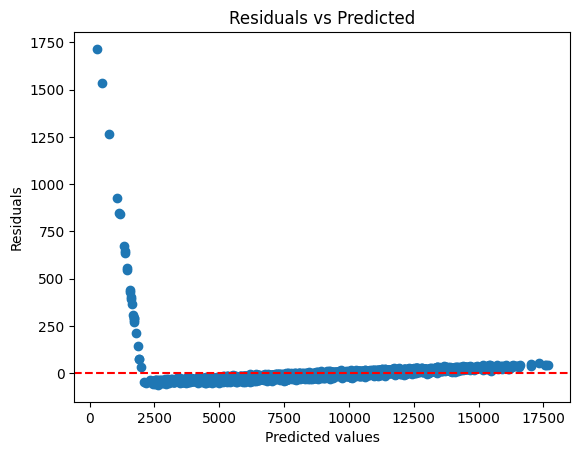

```python
#plotting the residuals and predcted values
import matplotlib.pyplot as plt

# Residuals plot
y_pred=model.predict(X_test)
residuals = y_test - y_pred
plt.scatter(y_pred, residuals)
plt.axhline(0, color='red', linestyle='--')
plt.xlabel('Predicted values')
plt.ylabel('Residuals')
plt.title('Residuals vs Predicted')
plt.show()
```

Linear Regression using statsmodel

```python
import statsmodels.api as sm
X_train=sm.add_constant(X_train)
model1=sm.OLS(y_train,X_train).fit()
print(model1.summary())
```

```
                            OLS Regression Results
==============================================================================
Dep. Variable:                  Price   R-squared:                       0.999
Model:                            OLS   Adj. R-squared:                  0.999
Method:                 Least Squares   F-statistic:                 2.045e+05
Date:                Sat, 15 Feb 2025   Prob (F-statistic):               0.00
Time:                        18:10:42   Log-Likelihood:                -41619.
No. Observations:                7000   AIC:                         8.332e+04
Df Residuals:                    6960   BIC:                         8.359e+04
Df Model:                          39
Covariance Type:            nonrobust
===============================================================================================
                                  coef    std err          t      P>|t|      [0.025      0.975]
-----------------------------------------------------------------------------------------------
const                       -5.403e+05    293.199  -1842.697      0.000   -5.41e+05    -5.4e+05
Year                          298.4776      0.160   1861.996      0.000     298.163     298.792
Engine_Size                   992.1897      0.962   1031.779      0.000     990.305     994.075
Mileage                     -1723.5342      1.112  -1550.138      0.000   -1725.714   -1721.355
Doors                          -1.3779      1.001     -1.376      0.169      -3.341       0.585
Owner_Count                     0.2042      0.783      0.261      0.794      -1.330       1.738
Brand_BMW                   -5.403e+04     29.789  -1813.802      0.000   -5.41e+04    -5.4e+04
Brand_Chevrolet             -4.052e+04     22.162  -1828.434      0.000   -4.06e+04   -4.05e+04
Brand_Ford                  -4.052e+04     22.152  -1829.160      0.000   -4.06e+04   -4.05e+04
Brand_Honda                 -4.051e+04     22.095  -1833.578      0.000   -4.06e+04   -4.05e+04
Brand_Hyundai               -4.052e+04     22.159  -1828.655      0.000   -4.06e+04   -4.05e+04
Brand_Kia                   -4.051e+04     22.144  -1829.615      0.000   -4.06e+04   -4.05e+04
Brand_Mercedes              -4.052e+04     22.107  -1832.780      0.000   -4.06e+04   -4.05e+04
Brand_Toyota                -4.052e+04     22.143  -1829.968      0.000   -4.06e+04   -4.05e+04
Brand_Volkswagen            -4.052e+04     22.145  -1829.834      0.000   -4.06e+04   -4.05e+04
Model_5 Series                 -3.2370      8.496     -0.381      0.703     -19.892      13.418
Model_A3                    -5.403e+04     29.901  -1806.958      0.000   -5.41e+04    -5.4e+04
Model_A4                    -5.403e+04     29.824  -1811.741      0.000   -5.41e+04    -5.4e+04
Model_Accord                -1.351e+04      8.858  -1524.825      0.000   -1.35e+04   -1.35e+04
Model_C-Class               -1.351e+04      9.063  -1490.296      0.000   -1.35e+04   -1.35e+04
Model_CR-V                  -1.351e+04      8.851  -1526.377      0.000   -1.35e+04   -1.35e+04
Model_Camry                 -1.351e+04      8.914  -1516.012      0.000   -1.35e+04   -1.35e+04
Model_Civic                  -1.35e+04      8.889  -1518.396      0.000   -1.35e+04   -1.35e+04
Model_Corolla               -1.351e+04      8.918  -1514.832      0.000   -1.35e+04   -1.35e+04
Model_E-Class               -1.351e+04      8.979  -1504.440      0.000   -1.35e+04   -1.35e+04
Model_Elantra               -1.351e+04      8.833  -1529.348      0.000   -1.35e+04   -1.35e+04
```

[output cut: 19 more lines]

```
Fuel_Type_Hybrid              988.0848      3.148    313.864      0.000     981.913     994.256
Fuel_Type_Petrol               -0.5927      3.146     -0.188      0.851      -6.759       5.574
Transmission_Manual         -1489.6781      2.717   -548.265      0.000   -1495.004   -1484.352
Transmission_Semi-Automatic -1492.0367      2.735   -545.590      0.000   -1497.398   -1486.676
==============================================================================
Omnibus:                    13502.043   Durbin-Watson:                   1.997
Prob(Omnibus):                  0.000   Jarque-Bera (JB):         22345519.976
Skew:                          15.246   Prob(JB):                         0.00
Kurtosis:                     278.106   Cond. No.                     1.25e+19
==============================================================================

Notes:
[1] Standard Errors assume that the covariance matrix of the errors is correctly specified.
[2] The smallest eigenvalue is 1.83e-28. This might indicate that there are
strong multicollinearity problems or that the design matrix is singular.
```

observations: .R-squared: 0.999-implies the model is a good fit. .Intercept -5.403e+05It is negative (-540,300), which suggests that the model's baseline price for a car would be negative if all other features (like Year, Engine_Size, Mileage, etc.) were zero. .3 significant features-Year ,Enginee are positively correlated and Mileage is highly negatively correlated. .some features like doors,owner count are statistically insignificant(p-val >.05)

```python
#checking for multicollinearity
from statsmodels.stats.outliers_influence import variance_inflation_factor
def check_vif(predictors):
    vif=pd.DataFrame()
    vif['feature']=predictors.columns
    vif['VIF']=[variance_inflation_factor(predictors.values,i)
            for i in range(predictors.shape[1])]
    print(vif)
```

```python
#checking multicollinearity
check_vif(X_train)
```

```
                        feature       VIF
0                         const  0.000000
1                          Year  1.004581
2                   Engine_Size  1.005310
3                       Mileage  1.006673
4                         Doors  1.005727
5                   Owner_Count  1.007918
6                     Brand_BMW       inf
7               Brand_Chevrolet       inf
8                    Brand_Ford       inf
9                   Brand_Honda       inf
10                Brand_Hyundai       inf
11                    Brand_Kia       inf
12               Brand_Mercedes       inf
13                 Brand_Toyota       inf
```

[output cut: 35 more lines]